# GLMM Analysis Report

## Methods

Model was fitted using **lme4::lmer**.

Family: **gaussian**

Formula: **lmer(smile ~ 1 + beer + (1 + beer | bar), control = lmerControl(optimizer = “bobyqa”), , data = df)**

Sample size used in this fit: **15 subjects**, **234 observations**.

## Model Fitting Diagnostics

This section reports diagnostics captured automatically at fit time and should be reviewed before interpreting the results below. A singular fit, a non-convergence message, or fitting warnings do not necessarily invalidate a model, but they do mean its estimates (particularly variance components) should be interpreted with caution.

| Check | Result |
| --- | --- |
| Singular fit | NO |
| Convergence | OK |

### Warnings raised during model fitting

*No warnings were raised while fitting this model.*

## Results

### Model Summary

Full summary output of the fitted model, as printed by R.

```
## Linear mixed model fit by REML. t-tests use Satterthwaite's method ['lmerModLmerTest']
## Formula: smile ~ 1 + beer + (1 + beer | bar)
##    Data: df
## Control: lmerControl(optimizer = "bobyqa")
##
## REML criterion at convergence: 810
##
## Scaled residuals:
##      Min       1Q   Median       3Q      Max
## -3.02947 -0.63560  0.05346  0.67707  2.67218
##
## Random effects:
##  Groups   Name        Variance Std.Dev. Corr
##  bar      (Intercept) 8.33512  2.8871
##           beer        0.02785  0.1669   -0.84
##  Residual             1.43136  1.1964
## Number of obs: 234, groups:  bar, 15
##
## Fixed effects:
##             Estimate Std. Error      df t value Pr(>|t|)
## (Intercept)   5.6726     0.8147 10.8893   6.963 2.51e-05 ***
## beer          0.5555     0.0925  7.2335   6.005 0.000476 ***
## ---
## Signif. codes:  0 '***' 0.001 '**' 0.01 '*' 0.05 '.' 0.1 ' ' 1
##
## Correlation of Fixed Effects:
##      (Intr)
## beer -0.697
```

### Random Effects

Both the **variance** (σ²) and the **standard deviation** (σ) of each random-effect term are shown. The residual row is the within-group (observation-level) variance.

Random-effects variance components

| Group | Effect | Variance | Std.Dev. |
| --- | --- | --- | --- |
| bar | (Intercept) | 8.33500 | 2.8870 |
| bar | beer | 0.02785 | 0.1669 |
| Residual | (Residual) | 1.43100 | 1.1960 |

Random-effects covariances and correlations

| Group | Effects | Covariance | Correlation |
| --- | --- | --- | --- |
| bar | (Intercept) ~ beer | -0.4061 | -0.8428 |

### Fixed Effects

Fixed Effects

|  | Estimate | Std. Error | df | t value | Pr(>\|t\|) |  |
| --- | --- | --- | --- | --- | --- | --- |
| (Intercept) | 5.673 | 0.815 | 11 | 6.963 | < 1e-04 | *** |
| beer | 0.555 | 0.093 | 7 | 6.005 | 0.000476 | *** |

### ANOVA (Type III)

```
## Type III Analysis of Variance Table with Satterthwaite's method
##      Sum Sq Mean Sq NumDF  DenDF F value   Pr(>F)
## beer  51.61   51.61     1 7.2335  36.057 0.000476 ***
## ---
## Signif. codes:  0 '***' 0.001 '**' 0.01 '*' 0.05 '.' 0.1 ' ' 1
```

### Model Performance

Variance explained and clustering (R2, ICC)

| Metric | Value |
| --- | --- |
| R2 marginal (fixed effects only) | 0.08976 |
| R2 conditional (fixed + random effects) | 0.82240 |
| ICC (adjusted) | 0.80490 |
| ICC (unadjusted) | 0.73270 |

Information criteria and error measures

| Metric | Value |
| --- | --- |
| AIC | 822.000 |
| AICc | 822.400 |
| BIC | 842.800 |
| RMSE | 1.152 |
| Sigma | 1.196 |

**How to read these measures**

- **R2 marginal**: proportion of variance explained by the fixed effects alone.
- **R2 conditional**: proportion of variance explained by the fixed and random effects together.
- **ICC**: proportion of the total (non-fixed-effect) variance attributable to differences between groups/subjects; higher values mean observations within the same group are more alike.
- This model was fitted by REML: AIC/BIC are only comparable between models with identical fixed effects. Refit by ML to compare models with different fixed effects.

### DHARMa Residual Diagnostics

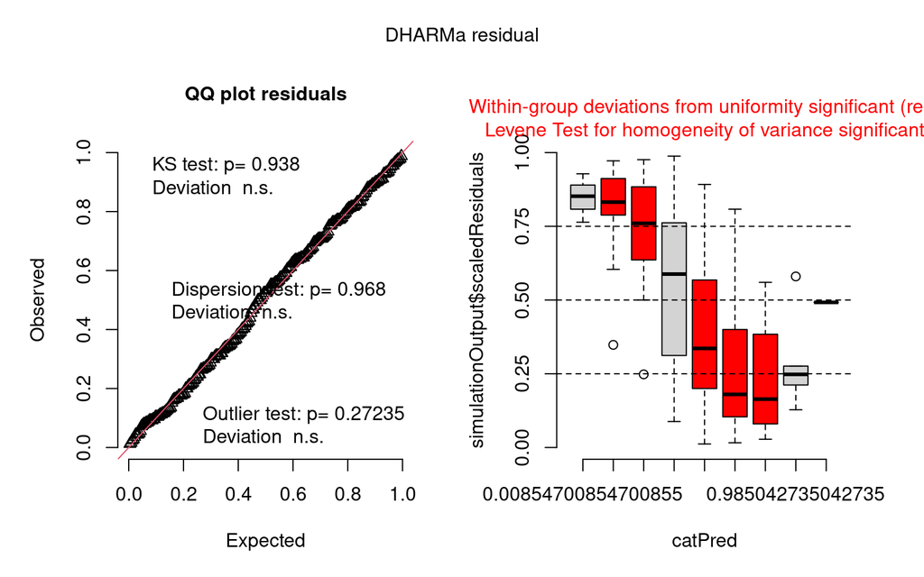